# Reproducible Research: Peer Assessment 1

## Loading and preprocessing the data

```r
activity <- read.csv("activity.csv")
activity$date <- as.Date(activity$date, format='%Y-%m-%d')
```

## What is mean total number of steps taken per day?

#### 1.Make a histogram of the total number of steps taken each day

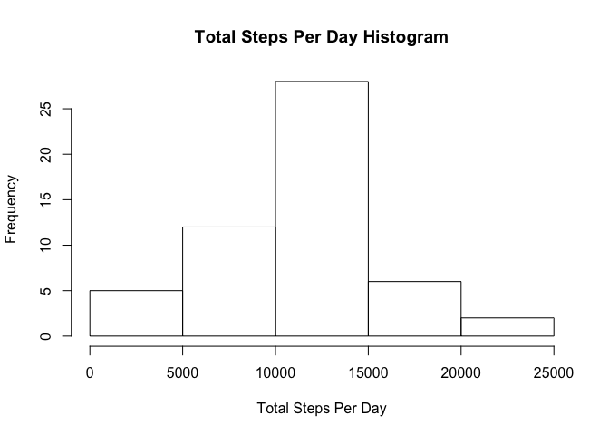

```r
totalstepsperday <- aggregate(activity$steps~activity$date,activity,sum)
colnames(totalstepsperday) <- c("Date", "Steps")
hist(totalstepsperday$Steps, xlab = "Total Steps Per Day", main = "Total Steps Per Day Histogram")
```

#### 2.Calculate and report the mean and median total number of steps taken per day

```r
mean(totalstepsperday$Steps)
```

```
## [1] 10766
```

```r
median(totalstepsperday$Steps)
```

```
## [1] 10765
```

## What is the average daily activity pattern?

#### 1. Make a time series plot (i.e. type = “l”) of the 5-minute interval (x-axis) and the average number of steps taken, averaged across all days (y-axis)

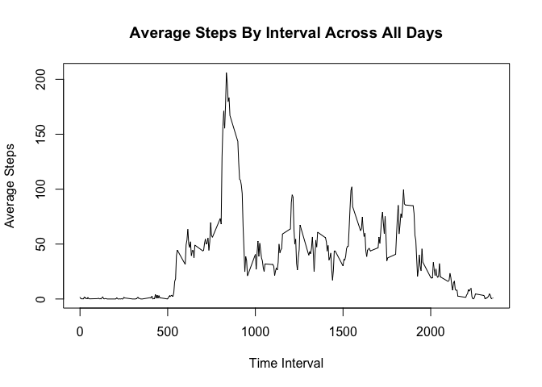

```r
tspinterval <- aggregate(activity$steps~activity$interval,activity,mean)
colnames(tspinterval) <- c("Interval", "Steps")
plot(tspinterval$Interval,tspinterval$Steps,type = "l", xlab = "Time Interval", ylab = "Average Steps", main = "Average Steps By Interval Across All Days")
```

#### 2. Which 5-minute interval, on average across all the days in the dataset, contains the maximum number of steps?

```r
maxsteps <- which.max(tspinterval$Steps)
tspinterval$Interval[maxsteps]
```

```
## [1] 835
```